# ESM204_a3_Art_Somhegyi_Berkovitz

Olivia Somhegyi, Simone Berkovitz, and Kristin Art

2023-05-16

```r
knitr::opts_chunk$set(echo = TRUE, warning = FALSE, message = FALSE, results = TRUE)
library(here)
library(tidyverse)
library(janitor)
library(dplyr)
library(pracma)
library(purrr)
library(wesanderson)
library(stargazer)
library(kableExtra)
library(equatiomatic)
```

### Distributional consequences of the clean energy transition

## Question 1

DAC has a lower demand for EVs compared to non-DAC consumers because they tend to have a lower income and lower marginal willingness-to-pay for EVs. DAC consumer demand is more inelastic than non-DAC consumers, meaning the change in price influences change in demand less for DAC consumers than non-DAC consumers. DAC might also have lower demand due to less access to EV charging infrastructure.

```r
#load in data
ev_raw = read_csv(here("a3/HW3_data.csv"))

#clean names and pivot longer
ev_df = ev_raw %>%
  janitor::clean_names() %>%
  rename('p'= 1, 'dac' = 2,'non_dac' = 3) %>%
  pivot_longer(cols = dac:non_dac, names_to = "community", values_to = "q")

#run linear regression on raw data and save model's coefficients and intercept for each community
models = ev_df %>%
  group_by(community) %>%
  nest() %>%
  mutate(reg = purrr::map(.x = data, ~lm(p~q, data = .x)), #create regression column
         coeff = map_dbl(reg, ~ coefficients(.x)["q"]), #create column w/ lm coefficients
         int = map_dbl(reg, ~ coefficients(.x)["(Intercept)"])) %>%  #create column w/ lm intercept
  select(-c(data,reg)) #only select columns of interest

#define model outputs as objects for ease of use
#slopes
dac_slope = models$coeff[models$community == 'dac']
non_slope = models$coeff[models$community == 'non_dac']
#intercepts
dac_int = models$int[models$community == 'dac']
non_int = models$int[models$community == 'non_dac']
```

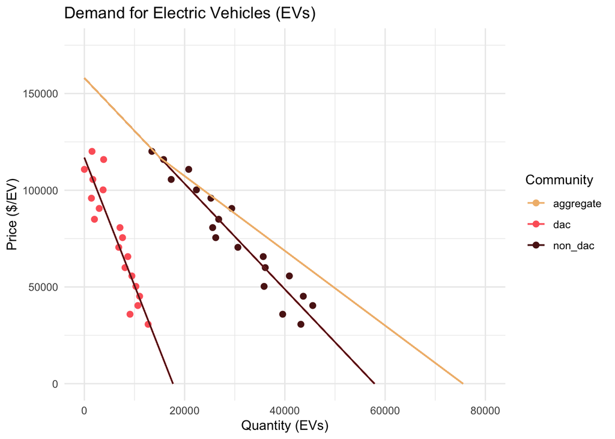

```r
#plot demand estimates and lm curves
plot_1 =
  ggplot(ev_df, aes(x = q, y = p, color = community)) +
  geom_point(size = 2) +
  #geom_abline(slope = dac_slope, intercept = dac_int) +
  #geom_abline(slope = non_slope, intercept = non_int) + #don't know how to clip the ablines where they cross the axes, so plotted with segment instead
  geom_segment(data = ev_df, x = 0, y = non_int, xend = 57868.38, yend = 0)+
  geom_segment(data = ev_df, x = 0, y = dac_int, xend = 17674.65, yend = 0)+
  geom_segment(data = ev_df, aes(x = 0, y = non_int, xend = 15078.93, yend = dac_int, colour = "aggregate"))+
  geom_segment(data = ev_df, aes(x = 15078.93, y = dac_int, xend = 75543.04, yend = 0, colour = "aggregate"))+
  scale_color_manual(values= wes_palette("GrandBudapest1", n = 3)) +
  labs(x = "Quantity (EVs)", y =  "Price ($/EV)", color = "Community", title = "Demand for Electric Vehicles (EVs)") +
  ylim(0,175000)+
  xlim(0,80000)+
  theme_minimal() +
  theme()

plot_1
```

## Question 2

```r
li_mc = 300 #marginal cost of 1 kg of lithium mined for batteries
n_li = 63 #kg of lithium used in one EV

ev_MEC = li_mc*n_li
```

If the marginal externality cost of 1 kg of lithium is $300 and 63 kg of lithium are used during the production of one EV, then the marginal externality cost per EV produced is $1.89^{4}.

## Question 3

```r
#define demand functions
#define generic demand function to calculate Q
compute_d_Q = function(P, int, slope){
  Q = (P - int)/ slope
  return(Q)
}

#define aggregate demand function to solve for Q
agg_d_Q = function(P){
  #if the input price is equal to or greater than the intercept of the DAC curve, then calculate Q based on the non-DAC curve alone
  if(P >= dac_int) {
    Q_agg  = compute_d_Q(P = P, int = non_int, non_slope)}

  #if the input price is less than the intercept of the DAC curve, then calculate Q by adding the demand curves for both DAC and non-DAC
  if(P < dac_int) {
    Q_agg = compute_d_Q(P = P, int = non_int, non_slope) + compute_d_Q(P = P, int = dac_int, dac_slope)
  }

  #return Q value from above situation based on the input P
  return(Q_agg)
}

#define generic demand function to calculate P
compute_d_P = function(Q, int, slope){
  P = int + slope*Q
  return(P)
}

#define aggregate demand function to solve for P
agg_d_P = function(Q){
  P = ((75543.03807 - Q)/0.517429209)
  return(P)
}

#find eq Q based on known eq P
P_eq = 50000
Q_eq = agg_d_Q(P_eq)

#calculate MPC slope based on rise/ run between (0,0) and (Q_eq, P_eq)
MPC_slope = P_eq/Q_eq

#define generic function to calculate consumer surplus, note can only use on individual demand curves, not aggregate (due to kinked curve)
compute_CS = function(P, int, slope){
  CS = 0.5*(int - P)*(compute_d_Q(P, int, slope))
  return(CS)
}

#find consumer surplus by adding CS for each community
CS = (compute_CS(P = P_eq, int = dac_int, slope = dac_slope)) + (compute_CS(P = P_eq, int = non_int, slope = non_slope))

#define marginal private cost curve to solve for P
MPC_P = function(Q){
  P = MPC_slope*Q
  return(P)
}

#define marginal social cost curve to solve for P
MSC_P = function(Q){
  P = ev_MEC + MPC_slope*Q
  return(P)
}

#find producer surplus by calculating total area under supply curve
PS = integral(f = MPC_P, xmin = 0, xmax = Q_eq)

#find total environmental damage
TC_env = ev_MEC*Q_eq
```

1. Aggregate annual demand curve for EVs

For DAC communities, the demand curve for EVs is given by P = 1.1685484^{5} + -6.6114372*Q. Rearranged, the demand curve is Q = (P - 1.1685484^{5})/ -6.6114372.

For non-DAC communities, the demand curve for EVs is given by P = 1.5803428^{5} + -2.7309265*Q. Rearranged, the demand curve is Q = (P - 1.5803428^{5})/ -2.7309265.

2. Supply curve for EVs is given by P = 1.0066121*Q, or
   $$P = 1.006612Q$$
3. The “benefit” to consumers under the status quo, also known as the consumer surplus, is 2.4749129^{9}.
4. The “benefit” to producers under the status quo, also known as the producer surplus, is 1.2417892^{9}.
5. The total environmental cost under the status quo is 9.3879265^{8}

## Question 4

```r
#find consumer surplus for each community
dac_CS = compute_CS(P = P_eq, int = dac_int, dac_slope)
non_CS = compute_CS(P = P_eq, int = non_int, non_slope)

#calculate the percent of the total CS that each community receives
dac_perc_CS = round((dac_CS/(dac_CS + non_CS))*100)
non_perc_CS = round((non_CS/(dac_CS + non_CS))*100)

#show results in a table
names = c("DAC", "Non-DAC", "Total")
cs = c(round(dac_CS), round(non_CS), round(CS))
perc = c("14%", "86%", "100%")
table_1 = cbind(names, cs, perc)

kable(table_1, format = "markdown", caption = "Table 1: Breakdown of consumer benefits in the traditional market", col.names = c("Community", "Consumer Benefit ($)", "% Total"))
```

Table 1: Breakdown of consumer benefits in the traditional market

| Community | Consumer Benefit ($) | % Total |
| --- | --- | --- |
| DAC | 338017962 | 14% |
| Non-DAC | 2136894908 | 86% |
| Total | 2474912870 | 100% |

Non-DAC consumers receive 86% of the current consumer benefits, while DAC consumers only receive 14% of the current consumer benefits. The total consumer surplus is $2.4749129^{9}.

## Question 5

```r
#define socially optimal tax
tax_so = ev_MEC

#calculate socially optimal P by adding so tax to previous P eq
P_so = P_eq + ev_MEC

#then solve for Q by plugging into agg demand curve
Q_so = agg_d_Q(P_so)

#find the quantity difference between market equilibrium and socially optimal equilibrium
Q_diff = Q_eq - Q_so

#find the quantity difference between market equilibrium and socially optimal equilibrium
P_diff = P_so - P_eq

#calculate the total welfare of nonDAC as the CS
TW_non_so = compute_CS(P_so, non_int, non_slope)

#calculate the total environmental damage by multiplying the mec of one EV by the quantity consumed
TC_env = Q_so*ev_MEC

#calculate the total tax revenue generated, which is equivalent to total env damage
TB_tax = Q_so*tax_so

#calculate the total welfare of DAC as the CS - total environmental damage
TW_dac_so = compute_CS(P_so, dac_int, dac_slope) - TC_env

#calculate the producer surplus as the area under the supply curve - total environmental damage
PS_so = integral(f = MSC_P, xmin = 0, xmax = Q_so) - TC_env
PS_diff = PS - PS_so

#show results in a table
table_2 = bind_cols("Variable" = c("Price", "Quantity", "Non-DAC Welfare", "DAC Welfare", "Producer Surplus", "Total Environmental Damage", "Total Tax Revenue"),
                  "Value" = c(P_so, Q_so, TW_non_so, TW_dac_so, PS_so, TC_env, TB_tax))

kable(table_2, format = "markdown", caption = "Table 2: Market equilibrium and surpluses under socially optimal tax")
```

Table 2: Market equilibrium and surpluses under socially optimal tax

| Variable | Value |
| --- | --- |
| Price | 68900.00 |
| Quantity | 39892.16 |
| Non-DAC Welfare | 1454619891.84 |
| DAC Welfare | -580046023.30 |
| Producer Surplus | 800953293.90 |
| Total Environmental Damage | 753961784.55 |
| Total Tax Revenue | 753961784.55 |

The socially optimal tax is equivalent to the marginal externality cost (MEC) of lithium mining and is 1.89^{4}.

1. When the EV tax is applied, the quantity of EVs produced and consumes decreases by 9779.4107998 to 3.9892158^{4}.
2. When the EV tax is applied, the price for EVs increases by 1.89^{4} to 6.89^{4}.
3. With the tax, the total welfare of non-DAC is 1.4546199^{9}.
4. With the tax, the total welfare of DAC is -5.8004602^{8}.
5. With the tax, the total welfare of producers decreases by 4.4083592^{8} to 8.0095329^{8}.
6. The total environmental damage is 7.5396178^{8}.
7. The total tax revenue generated is 7.5396178^{8}, which is equivalent to the total environmental damage.

## Question 6

```r
#calculate n of EVs consumed by each community  in traditional market
Q_eq_dac = dac_int/(MPC_slope + abs(dac_slope))
Q_eq_non = non_int/(MPC_slope + abs(non_slope))

#calculate proportion of EVs consumed by each community
Q_shares_dac = (Q_eq_dac/ (Q_eq_dac + Q_eq_non))
Q_shares_non = (Q_eq_non/ (Q_eq_dac + Q_eq_non))

#calculate percentage of EVs consumed by each community
Q_perc_dac = round(100*Q_shares_dac)
Q_perc_non = round(100*Q_shares_non)
```

DAC consumed 27% of the EVs while non-DAC consumed 73% of the EVs.

```r
#method 1
#create df of potential li mecs
li_mec = c(300, 350, 400, 450, 500)
li_mec = as.data.frame(li_mec)

#calculate the things
welfare_results = li_mec %>%
  mutate(ev_mec = as.numeric(n_li*li_mec),
         p_so = as.numeric(P_eq + ev_mec),
         q_so = as.numeric(purrr::map(.x = p_so, .f = agg_d_Q)),
         non_CS = as.numeric(purrr::map(.x = p_so, non_int, non_slope, .f = compute_CS)),
         dac_CS = as.numeric(purrr::map(.x = p_so, dac_int, dac_slope, .f = compute_CS)),
         tax_rev = as.numeric(ev_mec*Q_so),  #this is also the MEC
         non_tax_rev = as.numeric(Q_shares_non*tax_rev),
         dac_tax_rev = as.numeric(Q_shares_dac*tax_rev),
         non_TW = as.numeric(non_CS + non_tax_rev),
         dac_TW = as.numeric(dac_CS + dac_tax_rev - q_so*tax_rev),
         p_TW = as.numeric(0.5*(q_so)*(p_so - ev_mec))) %>%
  select(li_mec, non_TW, dac_TW, p_TW)

#report in a table
kable(welfare_results, format = "markdown", caption = "Table 3: Total welfare for three groups based on the given scenario", col.names = c("Lithium MEC", "Non-DAC Total Welfare", "DAC Total Welfare", "Producers Total Welfare"))
```

[output not shown]

```r
#method 2
#define function to calculate welfare of three groups
summarize_welfare = function(li_mec){
  #compute mec of evs by multiplying cost of 1 kg lithium by number of lithium used in one ev
  ev_mec = li_mec*n_li

  #compute socially optimal price as the traditional market price + ev mec
  p_so = ev_mec + P_eq

  #define agg demand curve function without the piecewise situation, since it won't knit otherwise -_-
  agg_d_Q = function(P){
    Q_agg = compute_d_Q(P = P, int = non_int, non_slope) + compute_d_Q(P = P, int = dac_int, dac_slope)
    return(Q_agg)
  }

  #compute socially optimal q
  q_so = agg_d_Q(p_so)

  #compute tax revenue, aka total env cost
  tax_rev = ev_mec*q_so
  env_cost = tax_rev*q_so

  #compute CS for each group
  non_CS = compute_CS(p_so, non_int, non_slope)
  dac_CS = compute_CS(p_so, dac_int, dac_slope)

  #compute share of tax rev each group will receive
  non_tax_rev = Q_shares_non*tax_rev
  dac_tax_rev = Q_shares_dac*tax_rev

  #compute total welfare of each group
  non_TW = non_CS + non_tax_rev
  dac_TW = dac_CS + dac_tax_rev - env_cost

  #find PS
  p_TW = 0.5*(q_so)*(p_so - ev_mec)

  #format results
  results = tibble(li_mec = li_mec, non_TW = non_TW, dac_TW = dac_TW, p_TW = p_TW)

  return(results)
}

#test function with one input
test_results = summarize_welfare(300)

#create df of potential li mecs
li_mec = c(300, 350, 400, 450, 500)
li_mec = as.data.frame(li_mec)

#apply function to potential li mecs
welfare_results = map_dfr(li_mec, summarize_welfare)

#report in a table
kable(welfare_results, format = "markdown", caption = "Table 3: Total welfare for three groups based on the given scenario", col.names = c("Lithium MEC", "Non-DAC Total Welfare", "DAC Total Welfare", "Producers Total Welfare"))
```

Table 3: Total welfare for three groups based on the given scenario

| Lithium MEC | Non-DAC Total Welfare | DAC Total Welfare | Producers Total Welfare |
| --- | --- | --- | --- |
| 300 | 2007874695 | -3.007679e+13 | 997303948 |
| 350 | 1972715993 | -3.228083e+13 | 956556403 |
| 400 | 1933655767 | -3.381624e+13 | 915808858 |
| 450 | 1890694017 | -3.473324e+13 | 875061313 |
| 500 | 1843830743 | -3.508203e+13 | 834313768 |

## Question 7

1. The presence of climate change damages from gasoline cars decreases the optimal EV tax in California because EVs offset climate change impacts. By decreasing the optimal EV tax in California, EV demand will increase, which will lead to a reduction in gasoline cars and a reduction in climate change damages.
2. Non-DAC consumers would favor the tax because it would be a lower tax on EVs overall. Non-DAC consumers have a higher demand for EVs, therefore are benefitting from the lower tax because they are paying less. Additionally, they will not experience the direct environmental impacts from increased lithium mining due to the increased demand for EVs.
3. DAC consumers would not be in favor of the tax because it would lead to more lithium mining. DAC consumers have a lower demand for EVs and they experience the direct environmental impacts from mining more than the impacts from climate change. Thus, if there is more lithium mining occurring from a lower tax and an increased overall demand for EVs, DAC communities would bear the direct environmental impacts from the increased lithium mining.